# DOMAIN: Medical

• CONTEXT: Medical research university X is undergoing a deep research on patients with certain conditions. University has an internal AI team. Due to confidentiality the patient’s details and the conditions are masked by the client by providing different datasets to the AI team for developing a AIML model which can predict the condition of the patient depending on the received test result

# DATA DESCRIPTION:

```
The data consists of biomechanics features of the patients according to their current conditions. Each patient is
```

represented in the data set by six biomechanics attributes derived from the shape and orientation of the condition to their body part.

# PROJECT OBJECTIVE:

```
To Demonstrate the ability to fetch, process and leverage data to generate useful predictions by training Supervised
```

Learning algorithms

# STEPS AND TASK [30 Marks]:

# 1. Data Understanding: [5 Marks]

```python
# 1A. Read all the 3 CSV files as DataFrame and store them into 3 separate variables. [1 Mark]

import numpy as np
import pandas as pd
import seaborn as sns
import matplotlib.pyplot as plt # library used for plotting to visualise data
%matplotlib inline
# The %matplotlib inline enables “inline plotting”, where plotted graphics appear in your notebook
```

```python
# reading all 3 CSV files as Data Frame and storingn into 3 seperate variables

df1=pd.read_csv('Normal.csv')
df2=pd.read_csv('Type_H.csv')
df3=pd.read_csv('Type_S.csv')
```

```python
#1B. Print Shape and columns of all the 3 DataFrames. [1 Mark]
df1.shape # to check number of rows and columns i.e 100 rows and 7 columns in 1st data frame in this case
```

```
(100, 7)
```

```python
df1.info() # to check the attributes/column type of first data set
df1.head() # to check whether data loaded propoerly or not
```

```
<class 'pandas.core.frame.DataFrame'>
RangeIndex: 100 entries, 0 to 99
Data columns (total 7 columns):
 #   Column       Non-Null Count  Dtype
---  ------       --------------  -----
 0   P_incidence  100 non-null    float64
 1   P_tilt       100 non-null    float64
 2   L_angle      100 non-null    float64
 3   S_slope      100 non-null    float64
 4   P_radius     100 non-null    float64
 5   S_Degree     100 non-null    float64
 6   Class        100 non-null    object
dtypes: float64(6), object(1)
memory usage: 5.6+ KB
```

|  | P_incidence | P_tilt | L_angle | S_slope | P_radius | S_Degree | Class |
| --- | --- | --- | --- | --- | --- | --- | --- |
| 0 | 38.505273 | 16.964297 | 35.112814 | 21.540976 | 127.632875 | 7.986683 | Normal |
| 1 | 54.920858 | 18.968430 | 51.601455 | 35.952428 | 125.846646 | 2.001642 | Normal |
| 2 | 44.362490 | 8.945435 | 46.902096 | 35.417055 | 129.220682 | 4.994195 | Normal |
| 3 | 48.318931 | 17.452121 | 48.000000 | 30.866809 | 128.980308 | -0.910941 | Normal |
| 4 | 45.701789 | 10.659859 | 42.577846 | 35.041929 | 130.178314 | -3.388910 | Normal |

df2.shape

```python
df2.shape # to check number of rows and columns i.e 60 rows and 7 columns in 2nd data frame in this case
```

```
(60, 7)
```

```python
df2.info() #checking the attributes of 2nd dataset
df2.head() # checking for proper data loading in 2nd data set
```

```
<class 'pandas.core.frame.DataFrame'>
RangeIndex: 60 entries, 0 to 59
Data columns (total 7 columns):
 #   Column       Non-Null Count  Dtype
---  ------       --------------  -----
 0   P_incidence  60 non-null     float64
 1   P_tilt       60 non-null     float64
 2   L_angle      60 non-null     float64
 3   S_slope      60 non-null     float64
 4   P_radius     60 non-null     float64
 5   S_Degree     60 non-null     float64
 6   Class        60 non-null     object
dtypes: float64(6), object(1)
memory usage: 3.4+ KB
```

|  | P_incidence | P_tilt | L_angle | S_slope | P_radius | S_Degree | Class |
| --- | --- | --- | --- | --- | --- | --- | --- |
| 0 | 63.027817 | 22.552586 | 39.609117 | 40.475232 | 98.672917 | -0.254400 | Type_H |
| 1 | 39.056951 | 10.060991 | 25.015378 | 28.995960 | 114.405425 | 4.564259 | Type_H |
| 2 | 68.832021 | 22.218482 | 50.092194 | 46.613539 | 105.985135 | -3.530317 | Type_H |
| 3 | 69.297008 | 24.652878 | 44.311238 | 44.644130 | 101.868495 | 11.211523 | Type_H |
| 4 | 49.712859 | 9.652075 | 28.317406 | 40.060784 | 108.168725 | 7.918501 | Type_H |

```python
df3.shape # to check number of rows and columns i.e 150 rows and 7 columns in 3rd data frame in this case
```

```
(150, 7)
```

```python
df3.info() #checking the attributes of 3rd dataset
df3.head() # checking for proper data loading in 3rd data set
```

```
<class 'pandas.core.frame.DataFrame'>
RangeIndex: 150 entries, 0 to 149
Data columns (total 7 columns):
 #   Column       Non-Null Count  Dtype
---  ------       --------------  -----
 0   P_incidence  150 non-null    float64
 1   P_tilt       150 non-null    float64
 2   L_angle      150 non-null    float64
 3   S_slope      150 non-null    float64
 4   P_radius     150 non-null    float64
 5   S_Degree     150 non-null    float64
 6   Class        150 non-null    object
dtypes: float64(6), object(1)
memory usage: 8.3+ KB
```

|  | P_incidence | P_tilt | L_angle | S_slope | P_radius | S_Degree | Class |
| --- | --- | --- | --- | --- | --- | --- | --- |
| 0 | 74.377678 | 32.053104 | 78.772013 | 42.324573 | 143.560690 | 56.125906 | Type_S |
| 1 | 89.680567 | 32.704435 | 83.130732 | 56.976132 | 129.955476 | 92.027277 | Type_S |
| 2 | 44.529051 | 9.433234 | 52.000000 | 35.095817 | 134.711772 | 29.106575 | Type_S |
| 3 | 77.690577 | 21.380645 | 64.429442 | 56.309932 | 114.818751 | 26.931841 | Type_S |
| 4 | 76.147212 | 21.936186 | 82.961502 | 54.211027 | 123.932010 | 10.431972 | Type_S |

```python
# 1.C Compare Column names of all the 3 DataFrames and clearly write observations. [1 Mark]

# All the three data sets have same number of columns i.e 7 and column names are also same as below
# 1.P_incidence
# 2.P_tilt
# 3.L_angle
# 4.S_slope
# 5.P_radius
# 6.S_degree
# 7.Class
```

```python
#1.D Print DataTypes of all the 3 DataFrames. [1 Mark]
df1.info()
df2.info()
df3.info()
```

```
<class 'pandas.core.frame.DataFrame'>
RangeIndex: 100 entries, 0 to 99
Data columns (total 7 columns):
 #   Column       Non-Null Count  Dtype
---  ------       --------------  -----
 0   P_incidence  100 non-null    float64
 1   P_tilt       100 non-null    float64
 2   L_angle      100 non-null    float64
 3   S_slope      100 non-null    float64
 4   P_radius     100 non-null    float64
 5   S_Degree     100 non-null    float64
 6   Class        100 non-null    object
dtypes: float64(6), object(1)
memory usage: 5.6+ KB
<class 'pandas.core.frame.DataFrame'>
RangeIndex: 60 entries, 0 to 59
Data columns (total 7 columns):
 #   Column       Non-Null Count  Dtype
---  ------       --------------  -----
 0   P_incidence  60 non-null     float64
 1   P_tilt       60 non-null     float64
 2   L_angle      60 non-null     float64
 3   S_slope      60 non-null     float64
 4   P_radius     60 non-null     float64
 5   S_Degree     60 non-null     float64
 6   Class        60 non-null     object
dtypes: float64(6), object(1)
memory usage: 3.4+ KB
<class 'pandas.core.frame.DataFrame'>
RangeIndex: 150 entries, 0 to 149
Data columns (total 7 columns):
 #   Column       Non-Null Count  Dtype
---  ------       --------------  -----
 0   P_incidence  150 non-null    float64
 1   P_tilt       150 non-null    float64
 2   L_angle      150 non-null    float64
 3   S_slope      150 non-null    float64
 4   P_radius     150 non-null    float64
 5   S_Degree     150 non-null    float64
 6   Class        150 non-null    object
dtypes: float64(6), object(1)
memory usage: 8.3+ KB
```

```python
# from the above Dtype in info() function gives the datatypes of columns and here there are 6 float64 type and 1 object type column in each data set
```

```python
# 1E.Observe and share variation in ‘Class’ feature of all the 3 DataFrames. [1 Mark]

# while observing the data from the three data frames usind dataframe.head() , it is observed that they are differntiated with the values in 'class' column as below
# 1. Normal in 1st data frame
# 2. Type_H in 2nd data frame
# 3. Type_S in 3rd data frame

# The value in 'class' feature is differentiating the data frames
df1['Class'].unique()
```

```
array(['Normal', 'Nrmal'], dtype=object)
```

```python
# Counting the occurrences of each unique category
GroupedData1=df1.groupby(by='Class').size()
print(GroupedData1)
```

```
Class
Normal    73
Nrmal     27
dtype: int64
```

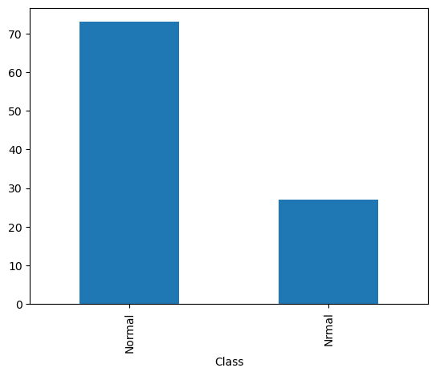

```python
GroupedData1.plot.bar()
```

```python
df2['Class'].unique()
```

```
array(['Type_H', 'type_h'], dtype=object)
```

```python
GroupedData2=df2.groupby(by='Class').size()
print(GroupedData2)
```

```
Class
Type_H    37
type_h    23
dtype: int64
```

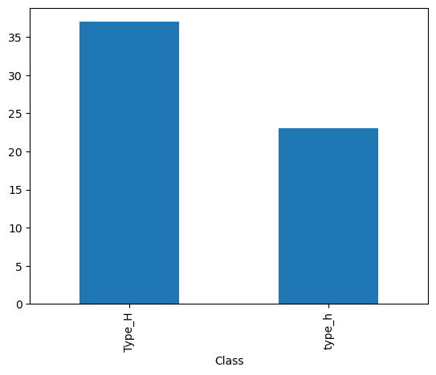

```python
GroupedData2.plot.bar()
```

```python
df3['Class'].unique()
```

```
array(['Type_S', 'tp_s'], dtype=object)
```

```python
GroupedData3=df3.groupby(by='Class').size()
print(GroupedData3)
```

```
Class
Type_S    133
tp_s       17
dtype: int64
```

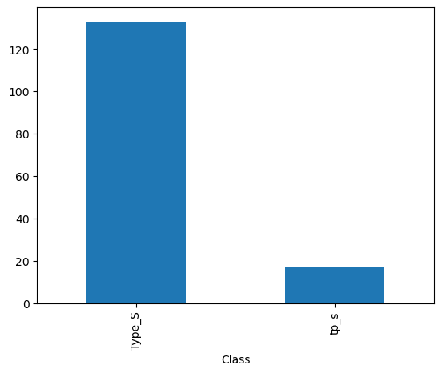

```python
GroupedData3.plot.bar()
```

# 2.Data Preparation and Exploration: [5 Marks]

```python
# 2A Unify all the variations in ‘Class’ feature for all the 3 DataFrames. [1 Marks]
df1.head()
df1copy=df1.copy()
df1copy.loc[df1copy['Class']=='Nrmal','Class']= 'Normal'
df1copy.head()
df1copy['Class'].unique()
df1copy.head()
# to unify the class feature checked for the unique values and conditionally changed the same to the desired value
```

|  | P_incidence | P_tilt | L_angle | S_slope | P_radius | S_Degree | Class |
| --- | --- | --- | --- | --- | --- | --- | --- |
| 0 | 38.505273 | 16.964297 | 35.112814 | 21.540976 | 127.632875 | 7.986683 | Normal |
| 1 | 54.920858 | 18.968430 | 51.601455 | 35.952428 | 125.846646 | 2.001642 | Normal |
| 2 | 44.362490 | 8.945435 | 46.902096 | 35.417055 | 129.220682 | 4.994195 | Normal |
| 3 | 48.318931 | 17.452121 | 48.000000 | 30.866809 | 128.980308 | -0.910941 | Normal |
| 4 | 45.701789 | 10.659859 | 42.577846 | 35.041929 | 130.178314 | -3.388910 | Normal |

```python
df2.head()
df2copy=df2.copy()
df2copy.loc[df2copy['Class']=='type_h','Class']= 'Type_H'
df2copy.head()
df2copy['Class'].unique()
# to unify the class feature checked for the unique values and conditionally changed the same to the desired value
```

```
array(['Type_H'], dtype=object)
```

```python
df3.head()
df3copy=df3.copy()
df3copy.loc[df3copy['Class']=='tp_s','Class']= 'Type_S'
df3copy.head()
df3copy['Class'].unique()
# to unify the class feature checked for the unique values and conditionally changed the same to the desired value
```

```
array(['Type_S'], dtype=object)
```

```python
# 2B. Combine all the 3 DataFrames to form a single DataFrame [1 Marks]
# Merging all the 3 datasets over rows
Biomechanics = pd.concat([df1copy,df2copy,df3copy],axis=0,ignore_index=True,sort=False)

Biomechanics['Class'].unique()
```

```
array(['Normal', 'Type_H', 'Type_S'], dtype=object)
```

```python
Biomechanics.head()
```

|  | P_incidence | P_tilt | L_angle | S_slope | P_radius | S_Degree | Class |
| --- | --- | --- | --- | --- | --- | --- | --- |
| 0 | 38.505273 | 16.964297 | 35.112814 | 21.540976 | 127.632875 | 7.986683 | Normal |
| 1 | 54.920858 | 18.968430 | 51.601455 | 35.952428 | 125.846646 | 2.001642 | Normal |
| 2 | 44.362490 | 8.945435 | 46.902096 | 35.417055 | 129.220682 | 4.994195 | Normal |
| 3 | 48.318931 | 17.452121 | 48.000000 | 30.866809 | 128.980308 | -0.910941 | Normal |
| 4 | 45.701789 | 10.659859 | 42.577846 | 35.041929 | 130.178314 | -3.388910 | Normal |

```python
# shape of combined dataset
Biomechanics.shape
# There are 310 rows and 7 Columns in the combined Data Set
```

```
(310, 7)
```

```python
#2C. Print 5 random samples of this DataFrame [1 Marks]
Biomechanics.sample(5)
```

|  | P_incidence | P_tilt | L_angle | S_slope | P_radius | S_Degree | Class |
| --- | --- | --- | --- | --- | --- | --- | --- |
| 30 | 41.646916 | 8.835549 | 36.031975 | 32.811367 | 116.555168 | -6.054538 | Normal |
| 281 | 64.624008 | 15.225303 | 67.632167 | 49.398705 | 90.298468 | 31.326411 | Type_S |
| 251 | 48.030624 | 3.969815 | 58.344519 | 44.060809 | 125.350962 | 35.000078 | Type_S |
| 180 | 77.106571 | 30.469994 | 69.480628 | 46.636577 | 112.151600 | 70.759083 | Type_S |
| 71 | 64.261507 | 14.497866 | 43.902504 | 49.763642 | 115.388268 | 5.951454 | Normal |

```python
#2D. Print Feature-wise percentage of Null values. [1 Mark]
#Biomechanics['Class'].value_counts() # There are 3 classes in the target variable.
```

```python
Biomechanics.isnull().sum()
```

```
P_incidence    0
P_tilt         0
L_angle        0
S_slope        0
P_radius       0
S_Degree       0
Class          0
dtype: int64
```

```python
#2E. Check 5-point summary of the new DataFrame. [1 Mark]

Biomechanics.describe().transpose()
```

|  | count | mean | std | min | 25% | 50% | 75% | max |
| --- | --- | --- | --- | --- | --- | --- | --- | --- |
| P_incidence | 310.0 | 60.496653 | 17.236520 | 26.147921 | 46.430294 | 58.691038 | 72.877696 | 129.834041 |
| P_tilt | 310.0 | 17.542822 | 10.008330 | -6.554948 | 10.667069 | 16.357689 | 22.120395 | 49.431864 |
| L_angle | 310.0 | 51.930930 | 18.554064 | 14.000000 | 37.000000 | 49.562398 | 63.000000 | 125.742385 |
| S_slope | 310.0 | 42.953831 | 13.423102 | 13.366931 | 33.347122 | 42.404912 | 52.695888 | 121.429566 |
| P_radius | 310.0 | 117.920655 | 13.317377 | 70.082575 | 110.709196 | 118.268178 | 125.467674 | 163.071041 |
| S_Degree | 310.0 | 26.296694 | 37.559027 | -11.058179 | 1.603727 | 11.767934 | 41.287352 | 418.543082 |

```python
#3. Data Analysis: [10 Marks]
#A. Visualize a heatmap to understand correlation between all features [2 Marks]

#A heat map is a two-dimensional representation of information with the help of colors.
#Heat maps can help the user visualize simple or complex information.

# To visualiase heatmap, the 'Class' fetaure should also need to be numerical
Biomechanics.iloc[:,6].unique()

# Use label encoder to convert categorical variables to one-hot encoding

from sklearn.preprocessing import LabelEncoder
class_label_encoder = LabelEncoder()

Biomechanics.iloc[:,-1] = class_label_encoder.fit_transform(Biomechanics.iloc[:,-1])
```

```python
Biomechanics.sample(5) # Check the encoded labels of target variable, 'Class'
```

|  | P_incidence | P_tilt | L_angle | S_slope | P_radius | S_Degree | Class |
| --- | --- | --- | --- | --- | --- | --- | --- |
| 69 | 48.801909 | 18.017762 | 52.000000 | 30.784147 | 139.150407 | 10.442862 | 0 |
| 208 | 63.172987 | 6.330911 | 63.000000 | 56.842076 | 110.644021 | 42.608076 | 2 |
| 14 | 89.834676 | 22.639217 | 90.563461 | 67.195460 | 100.501192 | 3.040973 | 0 |
| 275 | 56.563824 | 8.961262 | 52.577846 | 47.602562 | 98.777115 | 50.701873 | 2 |
| 67 | 65.756348 | 13.206926 | 44.000000 | 52.549422 | 129.393573 | -1.982120 | 0 |

```python
corr=Biomechanics.corr()
corr
```

|  | P_incidence | P_tilt | L_angle | S_slope | P_radius | S_Degree | Class |
| --- | --- | --- | --- | --- | --- | --- | --- |
| P_incidence | 1.000000 | 0.629199 | 0.717282 | 0.814960 | -0.247467 | 0.638743 | 0.537638 |
| P_tilt | 0.629199 | 1.000000 | 0.432764 | 0.062345 | 0.032668 | 0.397862 | 0.348231 |
| L_angle | 0.717282 | 0.432764 | 1.000000 | 0.598387 | -0.080344 | 0.533667 | 0.525466 |
| S_slope | 0.814960 | 0.062345 | 0.598387 | 1.000000 | -0.342128 | 0.523557 | 0.430734 |
| P_radius | -0.247467 | 0.032668 | -0.080344 | -0.342128 | 1.000000 | -0.026065 | -0.304099 |
| S_Degree | 0.638743 | 0.397862 | 0.533667 | 0.523557 | -0.026065 | 1.000000 | 0.608705 |
| Class | 0.537638 | 0.348231 | 0.525466 | 0.430734 | -0.304099 | 0.608705 | 1.000000 |